# Lab#2

Ifeoma Okonye

2024-01-30

To begin this lab session, I installed the *gapminder* data. I then called the library and displayed the first six rows of my dataset to survey the dataset and see the different variables in the data.

```r
#install.packages("gapminder")
library(gapminder)
data("gapminder")
head(gapminder, 6)
```

```
## # A tibble: 6 × 6
##   country     continent  year lifeExp      pop gdpPercap
##   <fct>       <fct>     <int>   <dbl>    <int>     <dbl>
## 1 Afghanistan Asia       1952    28.8  8425333      779.
## 2 Afghanistan Asia       1957    30.3  9240934      821.
## 3 Afghanistan Asia       1962    32.0 10267083      853.
## 4 Afghanistan Asia       1967    34.0 11537966      836.
## 5 Afghanistan Asia       1972    36.1 13079460      740.
## 6 Afghanistan Asia       1977    38.4 14880372      786.
```

Next, I re-ordered the data in reverse alphabetical order of countries and viewed the first 15 entries.

```r
country_reverse <- gapminder[order(gapminder$country, decreasing = TRUE), ]
head(country_reverse, 15)
```

```
## # A tibble: 15 × 6
##    country  continent  year lifeExp      pop gdpPercap
##    <fct>    <fct>     <int>   <dbl>    <int>     <dbl>
##  1 Zimbabwe Africa     1952    48.5  3080907      407.
##  2 Zimbabwe Africa     1957    50.5  3646340      519.
##  3 Zimbabwe Africa     1962    52.4  4277736      527.
##  4 Zimbabwe Africa     1967    54.0  4995432      570.
##  5 Zimbabwe Africa     1972    55.6  5861135      799.
##  6 Zimbabwe Africa     1977    57.7  6642107      686.
##  7 Zimbabwe Africa     1982    60.4  7636524      789.
##  8 Zimbabwe Africa     1987    62.4  9216418      706.
##  9 Zimbabwe Africa     1992    60.4 10704340      693.
## 10 Zimbabwe Africa     1997    46.8 11404948      792.
## 11 Zimbabwe Africa     2002    40.0 11926563      672.
## 12 Zimbabwe Africa     2007    43.5 12311143      470.
## 13 Zambia   Africa     1952    42.0  2672000     1147.
## 14 Zambia   Africa     1957    44.1  3016000     1312.
## 15 Zambia   Africa     1962    46.0  3421000     1453.
```

I then calculated and displayed the mean, median and standard deviation of the Life Life expectancy, Population, and GDPperCapita in the gapminder dataset.

```r
#Statistic for Life Expectancy
mean(gapminder$lifeExp)
```

```
## [1] 59.47444
```

```r
median(gapminder$lifeExp)
```

```
## [1] 60.7125
```

```r
sd(gapminder$lifeExp)
```

```
## [1] 12.91711
```

```r
#Statistic for Population
mean(gapminder$pop)
```

```
## [1] 29601212
```

```r
median(gapminder$pop)
```

```
## [1] 7023596
```

```r
sd(gapminder$pop)
```

```
## [1] 106157897
```

```r
#Statistic for GDP per Capita
mean(gapminder$gdpPercap)
```

```
## [1] 7215.327
```

```r
median(gapminder$gdpPercap)
```

```
## [1] 3531.847
```

```r
sd(gapminder$gdpPercap)
```

```
## [1] 9857.455
```

Additionally, I calculated the mean, median and standard deviation of the Life Life expectancy, Population, and GDPperCapita for each country and continent.

```r
#Calculating the mean, median and standard deviation for life expectancy, population and GDP per capita by country.

mean_stat <- aggregate(gapminder[ , c("lifeExp", "pop", "gdpPercap")],
                       by = gapminder["country"], FUN = mean, na.action = rm)
head(mean_stat, 5)
```

```
##       country  lifeExp      pop gdpPercap
## 1 Afghanistan 37.47883 15823715  802.6746
## 2     Albania 68.43292  2580249 3255.3666
## 3     Algeria 59.03017 19875406 4426.0260
## 4      Angola 37.88350  7309390 3607.1005
## 5   Argentina 69.06042 28602240 8955.5538
```

```r
median_stat <- aggregate(gapminder[ , c("lifeExp", "pop", "gdpPercap")],
                         by = gapminder["country"], FUN = median, na.action = rm)
head(median_stat, 5)
```

```
##       country lifeExp      pop gdpPercap
## 1 Afghanistan 39.1460 13473709  803.4832
## 2     Albania 69.6750  2644573 3253.2384
## 3     Algeria 59.6910 18593279 4853.8559
## 4      Angola 39.6945  6589530 3264.6288
## 5   Argentina 69.2115 28162601 9068.7844
```

```r
sd_stat <- aggregate(cbind(lifeExp, pop, gdpPercap) ~ country,
                     data = gapminder, FUN = sd, na.rm = TRUE)
head(sd_stat, 5)
```

```
##       country   lifeExp       pop gdpPercap
## 1 Afghanistan  5.098646 7114583.5  108.2029
## 2     Albania  6.322911  828585.5 1192.3515
## 3     Algeria 10.340069 8613355.3 1310.3377
## 4      Angola  4.005276 2672280.6 1165.9003
## 5   Argentina  4.186470 7546609.0 1862.5832
```

```r
#Calculating the mean, median and standard deviation for life expentancy, population and gdp per capita by continent.

mean_stat1 <- aggregate(gapminder[ , c("lifeExp", "pop", "gdpPercap")],
                        by = gapminder["continent"], FUN = mean, na.action = rm)
head(mean_stat1)
```

```
##   continent  lifeExp      pop gdpPercap
## 1    Africa 48.86533  9916003  2193.755
## 2  Americas 64.65874 24504795  7136.110
## 3      Asia 60.06490 77038722  7902.150
## 4    Europe 71.90369 17169765 14469.476
## 5   Oceania 74.32621  8874672 18621.609
```

```r
median_stat1 <- aggregate(gapminder[ , c("lifeExp", "pop", "gdpPercap")],
                          by = gapminder["continent"], FUN = median, na.action = rm)
head(median_stat1)
```

```
##   continent lifeExp      pop gdpPercap
## 1    Africa 47.7920  4579311  1192.138
## 2  Americas 67.0480  6227510  5465.510
## 3      Asia 61.7915 14530831  2646.787
## 4    Europe 72.2410  8551125 12081.749
## 5   Oceania 73.6650  6403492 17983.304
```

```r
sd_stat1 <- aggregate(gapminder[ , c("lifeExp", "pop", "gdpPercap")],
                      by = gapminder["continent"], FUN = function(x) sd(x, na.rm = T)) #alternative method
head(sd_stat1)
```

```
##   continent   lifeExp       pop gdpPercap
## 1    Africa  9.150210  15490923  2827.930
## 2  Americas  9.345088  50979430  6396.764
## 3      Asia 11.864532 206885205 14045.373
## 4    Europe  5.433178  20519438  9355.213
## 5   Oceania  3.795611   6506342  6358.983
```

I created a scatter plot of the global average Life expectancy over time and displayed the first 5 records for the dataset used to build the plot. I went ahead to Customize the display of the plot to make it easier to understand.

```r
avg_lifeExp <- aggregate(gapminder[ , "lifeExp"], by = gapminder["year"],
                         FUN = mean, na.action = rm)
head(avg_lifeExp, 5)
```

```
##   year  lifeExp
## 1 1952 49.05762
## 2 1957 51.50740
## 3 1962 53.60925
## 4 1967 55.67829
## 5 1972 57.64739
```

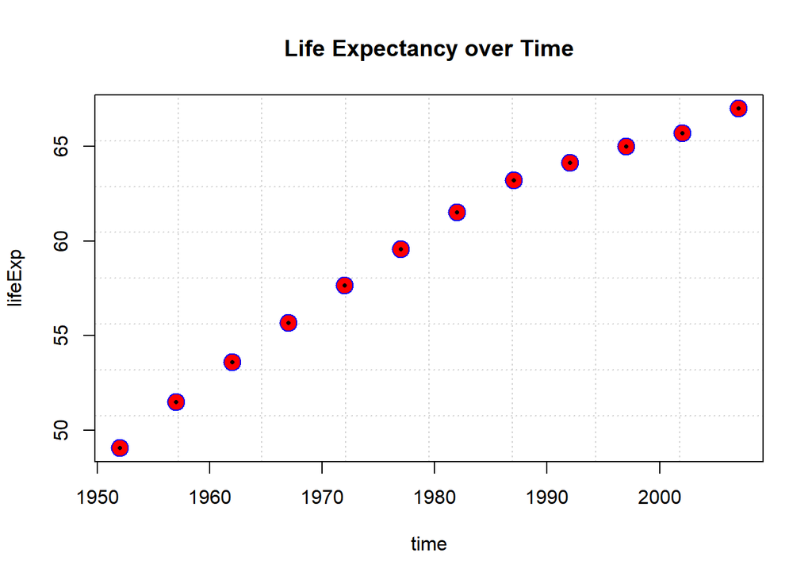

```r
time <- avg_lifeExp$year
lifeExp <- avg_lifeExp$lifeExp
plot(time, lifeExp,  panel.first = grid(8, 8),
     main = "Life Expectancy over Time", col = "blue", bg = "red", pch = 21, cex = 2)
points(time, lifeExp, col = "black", pch = 16, cex = 0.5)
```

I then pulled in the **Air Quality** dataset from the readily available R datasets and examined the structure. I looked at the class types, header information and the dimensions.

```r
data(airquality)
a_qal <- airquality

class(a_qal)
```

```
## [1] "data.frame"
```

```r
sapply(a_qal, class)
```

```
##     Ozone   Solar.R      Wind      Temp     Month       Day
## "integer" "integer" "numeric" "integer" "integer" "integer"
```

```r
head(a_qal, 10)
```

```
##    Ozone Solar.R Wind Temp Month Day
## 1     41     190  7.4   67     5   1
## 2     36     118  8.0   72     5   2
## 3     12     149 12.6   74     5   3
## 4     18     313 11.5   62     5   4
## 5     NA      NA 14.3   56     5   5
## 6     28      NA 14.9   66     5   6
## 7     23     299  8.6   65     5   7
## 8     19      99 13.8   59     5   8
## 9      8      19 20.1   61     5   9
## 10    NA     194  8.6   69     5  10
```

```r
ncol(a_qal)
```

```
## [1] 6
```

```r
nrow(a_qal)
```

```
## [1] 153
```

```r
dim(a_qal)
```

```
## [1] 153   6
```

I went ahead to calculate the general summary for the entire dataset. and then I calculated summary statistics for groups/subsets of the dataset.

```r
summary(a_qal, na.rm = TRUE)
```

```
##      Ozone           Solar.R           Wind             Temp
##  Min.   :  1.00   Min.   :  7.0   Min.   : 1.700   Min.   :56.00
##  1st Qu.: 18.00   1st Qu.:115.8   1st Qu.: 7.400   1st Qu.:72.00
##  Median : 31.50   Median :205.0   Median : 9.700   Median :79.00
##  Mean   : 42.13   Mean   :185.9   Mean   : 9.958   Mean   :77.88
##  3rd Qu.: 63.25   3rd Qu.:258.8   3rd Qu.:11.500   3rd Qu.:85.00
##  Max.   :168.00   Max.   :334.0   Max.   :20.700   Max.   :97.00
##  NA's   :37       NA's   :7
##      Month            Day
##  Min.   :5.000   Min.   : 1.0
##  1st Qu.:6.000   1st Qu.: 8.0
##  Median :7.000   Median :16.0
##  Mean   :6.993   Mean   :15.8
##  3rd Qu.:8.000   3rd Qu.:23.0
##  Max.   :9.000   Max.   :31.0
##
```

```r
summary(a_qal$Ozone, na.rm = TRUE)
```

```
##    Min. 1st Qu.  Median    Mean 3rd Qu.    Max.    NA's
##    1.00   18.00   31.50   42.13   63.25  168.00      37
```

```r
summary(a_qal$Temp, na.rm = TRUE)
```

```
##    Min. 1st Qu.  Median    Mean 3rd Qu.    Max.
##   56.00   72.00   79.00   77.88   85.00   97.00
```

```r
summary(a_qal$Solar.R, na.rm = TRUE)
```

```
##    Min. 1st Qu.  Median    Mean 3rd Qu.    Max.    NA's
##     7.0   115.8   205.0   185.9   258.8   334.0       7
```

```r
summary(a_qal$Wind, na.rm = TRUE)
```

```
##    Min. 1st Qu.  Median    Mean 3rd Qu.    Max.
##   1.700   7.400   9.700   9.958  11.500  20.700
```

```r
summary(a_qal$Month, na.rm = TRUE)
```

```
##    Min. 1st Qu.  Median    Mean 3rd Qu.    Max.
##   5.000   6.000   7.000   6.993   8.000   9.000
```

```r
summary(a_qal$Day, na.rm = TRUE)
```

```
##    Min. 1st Qu.  Median    Mean 3rd Qu.    Max.
##     1.0     8.0    16.0    15.8    23.0    31.0
```

Finally, I created 2 plots, one showing ungrouped data and the other showing grouped data. I gave each plot a title, descriptive x and y axis labels and customized a few graphic option on the plots.

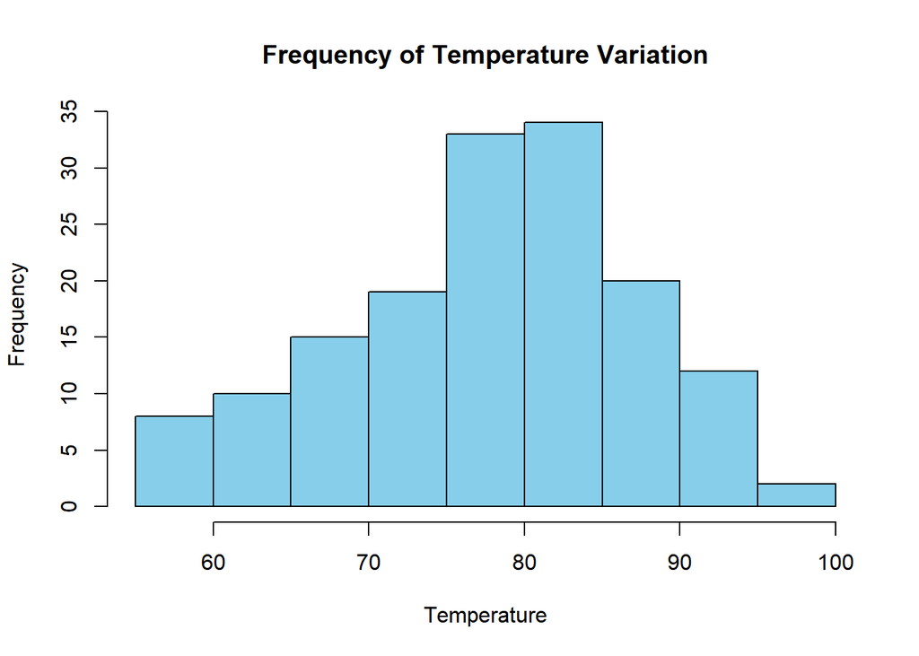

```r
# Ungrouped Plot
hist(a_qal$Temp, main = "Frequency of Temperature Variation", breaks = 12,
     col = "skyblue", xlab = "Temperature")
```

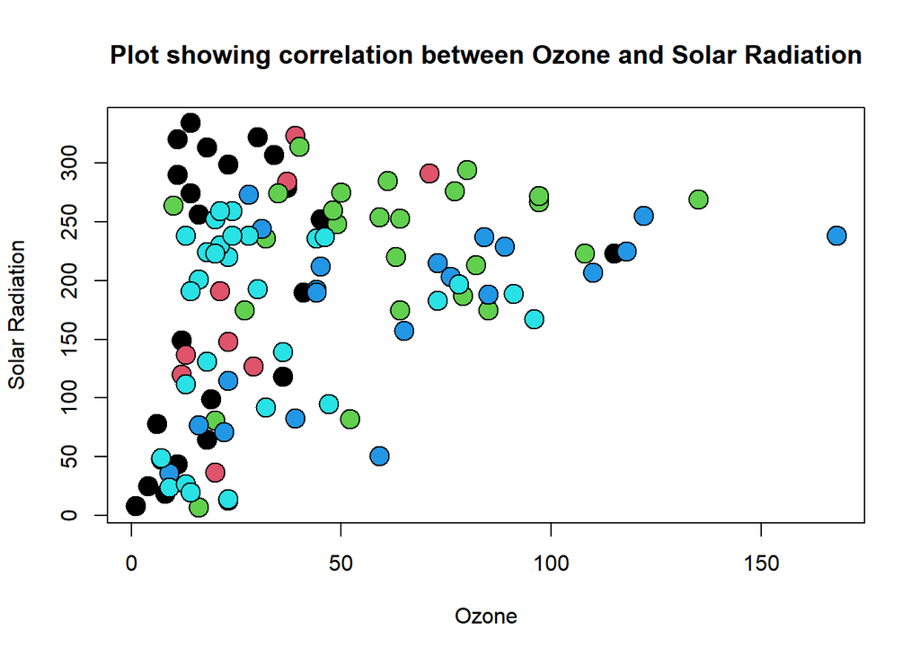

```r
# Grouped Plot
plot(a_qal$Ozone, a_qal$Solar.R,
     xlab = "Ozone", ylab = "Solar Radiation",
     main = "Plot showing correlation between Ozone and Solar Radiation",
     pch = 21, col = "black", bg = as.factor(a_qal$Month), cex = 2)
```

```r
?hist
```

```
## starting httpd help server ... done
```